# Assignment 7 - Unsupervised Learning II

Marko Konte

7/16/2019

# EDA

1. Summing all cost based variables. After capping and flooring the key data points we will sum each individual cost based variable. In order to get it prepared to run on a clustering model, we will then scale these figures.

```r
#Grouping values by procedure, state that shows the total of key cost based variables and identifying standard deviation of total payments

TotPayST <- payment %>% mutate(DRGState = paste(Provider.State,
                                               DRG.Definition, sep="_")) %>%
                                 dplyr::group_by(DRGState, Provider.Name) %>%
                  dplyr::summarise(Count = n(),
                   TotPay = sum(Average.Total.Payments), #Sums together of all total payments per procedure and state
                   TotCov = sum(Average.Covered.Charges), #Sums together all covered charges per procedure and state
                   TotMed = sum(Average.Medicare.Payments), #Sums together all medicare payments per procedure and state
                   TotDis = sum(Total.Discharges)) #Sums together all discharges per procedures and state


dim(TotPayST)
```

```
## [1] 162613      7
```

```r
summary(TotPayST)
```

```
##    DRGState                           Provider.Name        Count
##  Length:162613      GOOD SAMARITAN HOSPITAL  :   478   Min.   :1.000
##  Class :character   MERCY MEDICAL CENTER     :   357   1st Qu.:1.000
##  Mode  :character   MERCY HOSPITAL           :   347   Median :1.000
##                     ST JOSEPH MEDICAL CENTER :   347   Mean   :1.003
##                     ST JOSEPH HOSPITAL       :   295   3rd Qu.:1.000
##                     ST FRANCIS MEDICAL CENTER:   277   Max.   :3.000
##                     (Other)                  :160512
##      TotPay           TotCov           TotMed           TotDis
##  Min.   :  2673   Min.   :  2459   Min.   :  1149   Min.   :  11.0
##  1st Qu.:  5236   1st Qu.: 15944   1st Qu.:  4194   1st Qu.:  17.0
##  Median :  7221   Median : 25255   Median :  6167   Median :  27.0
##  Mean   :  9734   Mean   : 36234   Mean   :  8518   Mean   :  42.9
##  3rd Qu.: 11311   3rd Qu.: 43323   3rd Qu.: 10074   3rd Qu.:  49.0
##  Max.   :156158   Max.   :929119   Max.   :154621   Max.   :3383.0
##
```

2. Taking the differences from key variables. We will rely on total payments as a baseline and calculate the difference from medicare payments and covered charges. In addition, we will calculate the difference between covered charges and mediare per procedure and state.

```r
#Taking differences between numeric values to identify outliers in amount of cost per procedure + state

DiffVar <- payment %>% mutate(DRGState = paste(Provider.State,
                                                   DRG.Definition, sep="_")) %>%
                                    dplyr::group_by(DRGState, Provider.Name) %>%
                                    dplyr::summarise(Count = n(),
                   PayMedDiff = (sum(Average.Total.Payments)-sum(Average.Medicare.Payments)), #Total Payments minus Medicare payments. Negative value indicates more spent in Medicare than overall procedure.
                   CovMedDiff = (sum(Average.Covered.Charges)-sum(Average.Medicare.Payments)), #Covered charges minus medicare payments (negative value implies medicare spent more than was covered)
                   TotCovDiff = (sum(Average.Total.Payments)-sum(Average.Covered.Charges))) #Total Payments minus Covered Charges. Negative value indicates more spent on discharge covered charges than total payments


dim(DiffVar)
```

```
## [1] 162613      6
```

```r
summary(DiffVar)
```

```
##    DRGState                           Provider.Name        Count
##  Length:162613      GOOD SAMARITAN HOSPITAL  :   478   Min.   :1.000
##  Class :character   MERCY MEDICAL CENTER     :   357   1st Qu.:1.000
##  Mode  :character   MERCY HOSPITAL           :   347   Median :1.000
##                     ST JOSEPH MEDICAL CENTER :   347   Mean   :1.003
##                     ST JOSEPH HOSPITAL       :   295   3rd Qu.:1.000
##                     ST FRANCIS MEDICAL CENTER:   277   Max.   :3.000
##                     (Other)                  :160512
##    PayMedDiff        CovMedDiff       TotCovDiff
##  Min.   :    0.0   Min.   :-33997   Min.   :-798910
##  1st Qu.:  776.9   1st Qu.: 10757   1st Qu.: -32542
##  Median :  936.6   Median : 18611   Median : -17501
##  Mean   : 1216.3   Mean   : 27716   Mean   : -26500
##  3rd Qu.: 1226.0   3rd Qu.: 33851   3rd Qu.:  -9733
##  Max.   :75998.7   Max.   :804561   Max.   :  48255
##
```

3. Making key ratios from the cost based variables and total discharge. We will look at the ratio between covered charges and medicare to total payments. In addition, we identify the total payments per discharge, medicare payments per discharge, and covered payments per discharge.

```r
#Making ratios between all of the key numeric cost values
PercTot <- payment %>% mutate(DRGState = paste(Provider.State,
                                               DRG.Definition, sep="_")) %>%
            group_by(Provider.Name, DRGState) %>%
            dplyr::summarise(Count = n(),
                   TotalPayments = sum(Average.Total.Payments),
                   MedicarePayments = sum(Average.Medicare.Payments),
                   CoveredCharges = sum(Average.Covered.Charges),
                   Discharges = sum(Total.Discharges),
                   MedPerc = round(MedicarePayments/TotalPayments,2), #% of medicare payments to the total payments per procedure in a state.
                   CovPerc = round(CoveredCharges/TotalPayments,2), #% of covered changes to the total payments of procedures in a state
                   DisPerc = round(Discharges/TotalPayments,2), #% of total discharges to the total payments of a procedure.
                   MedPerDis = round(MedicarePayments/Discharges,2), #Average medicare payment per discharge for the procedure in a state
                   TotPerDis = round(TotalPayments/Discharges,2), #Average total payment per discharge for the procedure in a state
                   CovPerDis = round(CoveredCharges/Discharges,2)) %>% #Average total payment per discharge for the procedure in a state
            ungroup()


dim(PercTot)
```

```
## [1] 162613     13
```

```r
summary(PercTot)
```

```
##                    Provider.Name      DRGState             Count
##  GOOD SAMARITAN HOSPITAL  :   478   Length:162613      Min.   :1.000
##  MERCY MEDICAL CENTER     :   357   Class :character   1st Qu.:1.000
##  MERCY HOSPITAL           :   347   Mode  :character   Median :1.000
##  ST JOSEPH MEDICAL CENTER :   347                      Mean   :1.003
##  ST JOSEPH HOSPITAL       :   295                      3rd Qu.:1.000
##  ST FRANCIS MEDICAL CENTER:   277                      Max.   :3.000
##  (Other)                  :160512
##  TotalPayments    MedicarePayments CoveredCharges     Discharges
##  Min.   :  2673   Min.   :  1149   Min.   :  2459   Min.   :  11.0
##  1st Qu.:  5236   1st Qu.:  4194   1st Qu.: 15944   1st Qu.:  17.0
##  Median :  7221   Median :  6167   Median : 25255   Median :  27.0
##  Mean   :  9734   Mean   :  8518   Mean   : 36234   Mean   :  42.9
##  3rd Qu.: 11311   3rd Qu.: 10074   3rd Qu.: 43323   3rd Qu.:  49.0
##  Max.   :156158   Max.   :154621   Max.   :929119   Max.   :3383.0
##
##     MedPerc          CovPerc          DisPerc           MedPerDis
##  Min.   :0.0400   Min.   : 0.190   Min.   :0.000000   Min.   :    2.62
##  1st Qu.:0.8000   1st Qu.: 2.480   1st Qu.:0.000000   1st Qu.:  115.27
##  Median :0.8600   Median : 3.360   Median :0.000000   Median :  224.24
##  Mean   :0.8465   Mean   : 3.772   Mean   :0.004929   Mean   :  357.12
##  3rd Qu.:0.9100   3rd Qu.: 4.630   3rd Qu.:0.010000   3rd Qu.:  420.99
##  Max.   :1.0000   Max.   :23.610   Max.   :0.320000   Max.   :14056.44
##
##    TotPerDis          CovPerDis
##  Min.   :    3.16   Min.   :    2.69
##  1st Qu.:  141.19   1st Qu.:  444.40
##  Median :  271.33   Median :  883.95
##  Mean   :  406.81   Mean   : 1512.37
##  3rd Qu.:  485.80   3rd Qu.: 1754.20
##  Max.   :14196.20   Max.   :84465.35
##
```

## Capping and Flooring and creating final datasets

We wll now apply capping and flooring to the results of the features created. Next, we will scale these values which is the final preparation before we are ready to create the features that will be used in the modeling to be done.

```r
#Function for capping and flooring of data
#Capping and flooring
fun <- function(x){
  quantiles <- quantile( x, c(.05, .95 ) )
  x[ x < quantiles[1] ] <- quantiles[1]
  x[ x > quantiles[2] ] <- quantiles[2]
  x
}

#Capping and flooring total cost variable features
TotPayST <- TotPayST %>% mutate(TotPay = fun(TotPay),
                            TotCov = fun(TotCov),
                            TotMed = fun(TotMed),
                            TotDis = fun(TotDis))

#Scaling the figures from total scaled object above
Scaled <- TotPayST %>% mutate(ScTotPay = scale_this(TotPay),
                              ScTotCov = scale_this(TotCov),
                              ScTotMed = scale_this(TotMed),
                              ScTotDis = scale_this(TotDis)) %>%
  group_by(DRGState, Provider.Name)
Scaled$ScTotPay[is.na(Scaled$ScTotPay)] <- 0
Scaled$ScTotCov[is.na(Scaled$ScTotCov)] <- 0
Scaled$ScTotMed[is.na(Scaled$ScTotMed)] <- 0
Scaled$ScTotDis[is.na(Scaled$ScTotDis)] <- 0

#Capping and flooring difference variables
DiffVar <- DiffVar %>% mutate(PayMedDiff = fun(PayMedDiff),
                              CovMedDiff = fun(CovMedDiff),
                              TotCovDiff = fun(TotCovDiff))

#Scaling the values from above
DiffVarSc <- DiffVar %>% mutate(PayMedDiffSc = scale_this(PayMedDiff),
                                        CovMedDiffSc = scale_this(CovMedDiff),
                                        TotCovDiffSc = scale_this(TotCovDiff)) %>% ungroup()
DiffVarSc$PayMedDiffSc[is.na(DiffVarSc$PayMedDiffSc)] <- 0
DiffVarSc$CovMedDiffSc[is.na(DiffVarSc$CovMedDiffSc)] <- 0
DiffVarSc$TotCovDiffSc[is.na(DiffVarSc$TotCovDiffSc)] <- 0

#Capping and florring ratio variables
PercTot <- PercTot %>% mutate(MedPerc = fun(MedPerc),
                              CovPerc = fun(CovPerc),
                              DisPerc = fun(DisPerc),
                              MedPerDis = fun(MedPerDis),
                              TotPerDis = fun(TotPerDis),
                              CovPerDis = fun(CovPerDis))

#Scaling the ratio values created in the PercTot object
PercTotSc <- PercTot %>% mutate(ScMedPerc = scale_this(MedPerc),
                                ScCovPerc = scale_this(CovPerc),
                                ScDisPerc = scale_this(DisPerc),
                                ScMedPerDis = scale_this(MedPerDis),
                                ScTotPerDis = scale_this(TotPerDis),
                                ScCovPerDis = scale_this(CovPerDis))
```

## Making the final dataset

```r
#Model set with without any splitting

FinalDB <- payment %>% mutate(DRGState = paste(Provider.State,
                                               DRG.Definition, sep="_"))

FinalDB <- select(FinalDB, Provider.Id, Provider.Name, Provider.Zip.Code, Average.Covered.Charges,
                  Average.Total.Payments, Average.Medicare.Payments,Total.Discharges, DRGState)

#Scaled version of key numeric cost variables
FinalDB <- FinalDB %>% left_join(Scaled, by=c("DRGState", "Provider.Name"))

#Adding values from DIfferences Table
FinalDB <- FinalDB %>% left_join(DiffVarSc, by=c("DRGState","Provider.Name"))

#Adding scaled values from the percentages variables
FinalDB <- FinalDB %>% left_join(PercTotSc, by=c("DRGState","Provider.Name"))

#Train set setup
library(caTools)
split = sample.split(payment, SplitRatio = 0.4)
train = subset(payment, split == TRUE)
test = subset(payment, split == FALSE)

train <- train %>% mutate(DRGState = paste(Provider.State,
                                           DRG.Definition, sep="_"))

train <- select(train, Provider.Id, Provider.Name, Provider.Zip.Code,Average.Covered.Charges,
                Average.Total.Payments, Average.Medicare.Payments, Total.Discharges, DRGState)

#Scaled version of key numeric cost variables
train <- train %>% left_join(Scaled, by=c("DRGState", "Provider.Name"))

#Adding values from DIfferences Table
train <- train %>% left_join(DiffVarSc, by=c("DRGState","Provider.Name"))

#Adding scaled values from the percentages variables
train <- train %>% left_join(PercTotSc, by=c("DRGState","Provider.Name"))
```

# Singular Value Decomposition

SVD is an approach not unlike the PCA process with few important differences. The process creates three key variables:

D- Vector created by model which is akin to the standard deviation that is created by PCA models. However the SVD way of creating the D object forms by taking the sum of squares of the principal components but not dividing them by sample. This creates a ‘biased’ result and more representative to where the data is most significant.

U- Matrix created by model which contains left singular values which are representative of the rows in the initial dataset. These are orthogonal measurements which represent the positioning of the underlying datapoint within the original matrix.

V- 2nd matrix created which contains right singular values which are representative of the columns in the initial dataset. Like the U object, this is an orthogonal measurment which when combined together creates the standard deviation that is shown in the D object.

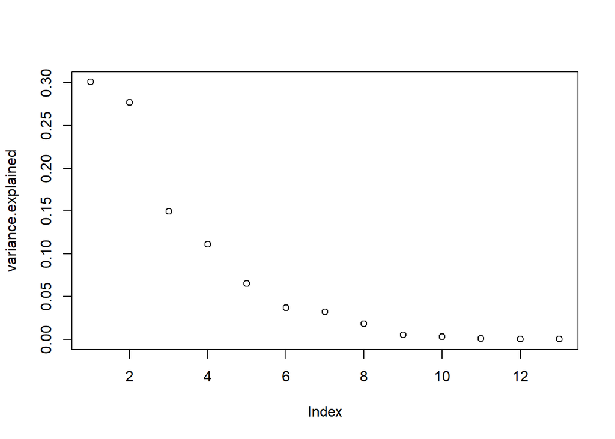

```r
svdb <- select(FinalDB, ScTotPay, ScTotCov, ScTotMed, ScTotDis,
               PayMedDiffSc, CovMedDiffSc, TotCovDiffSc,
               ScMedPerc, ScCovPerc, ScMedPerDis,
               ScTotPerDis, ScCovPerDis, ScDisPerc)
svd_model <- svd(svdb)

#Standard deviation of SVD model shown
variance.explained = prop.table(svd_model$d^2)
plot(variance.explained)
```

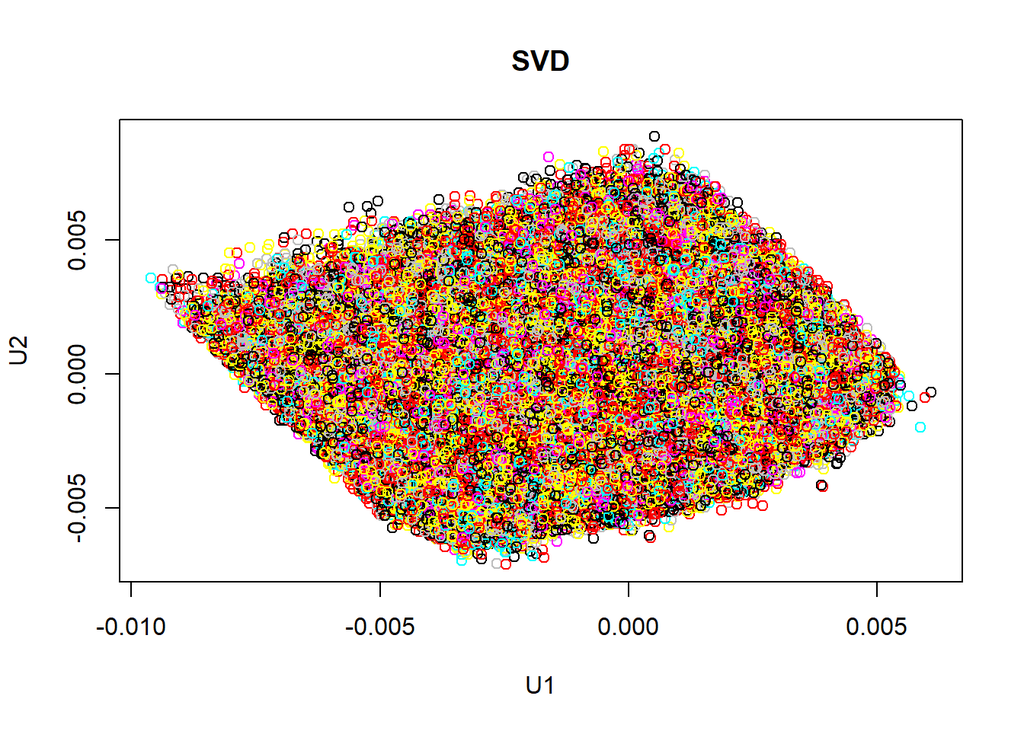

```r
#Plot of left singular values representing the rows
plot(svd_model$u[, 1], svd_model$u[, 2], col = svd_model$d, main = "SVD", xlab = "U1", ylab = "U2")
```

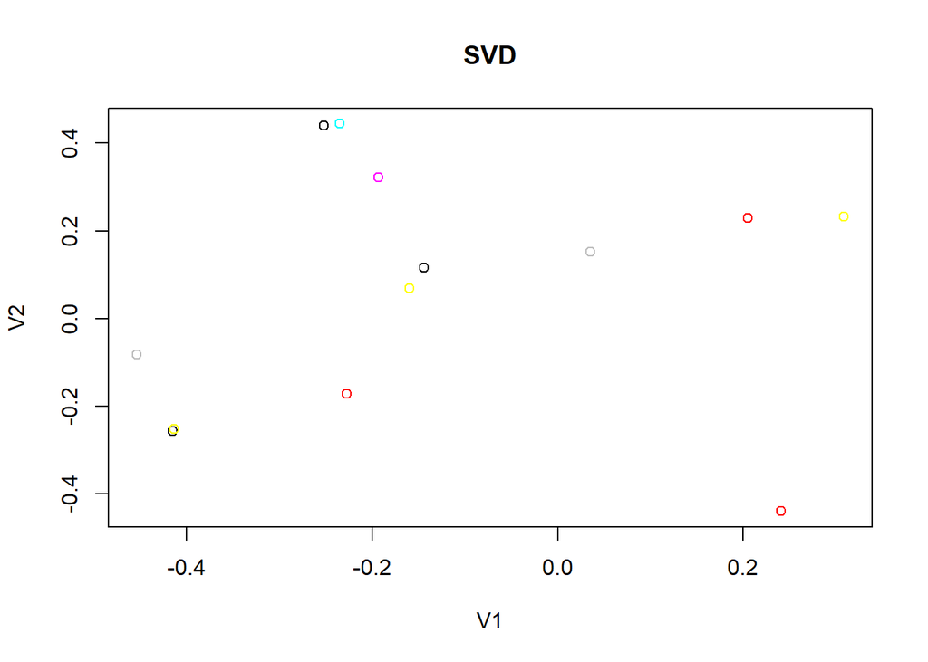

```r
#Right singular values representing columns
plot(svd_model$v[, 1], svd_model$v[, 2], col = svd_model$d, main = "SVD", xlab = "V1", ylab = "V2")
```

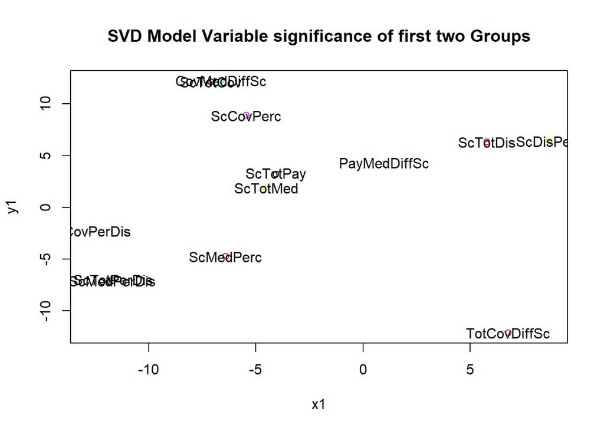

```
## integer(0)
```

```r
#Multiplying V variable by SD matrix to find significance
sdv <- svd_model$v %*% sqrt(diag(svd_model$d))
x1 <- sdv[,1]
y1 <- sdv[,2]

plot(x1, y1, col = svd_model$d, frame.plot = TRUE) +
  text(x1, y1, labels = colnames(svdb), title(main = 'SVD Model Variable significance of first two Groups'))
```

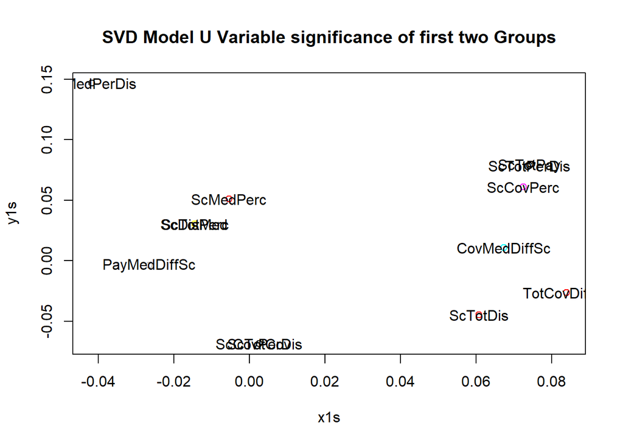

```
## integer(0)
```

```r
#Multiplying U Variable by SD matrix to find significance
sdu <- svd_model$u %*% sqrt(diag(svd_model$d))
x1u <- sdu[,1]
y1u <- sdu[,2]

#Since there are so many instances, will isolate the first 10 instances of the U variables
x1s <- x1u[1:10]
y1s <- y1u[1:10]

plot(x1s, y1s, col = svd_model$d, frame.plot = TRUE)+
  text(x1s, y1s, labels = colnames(svdb), title(main = 'SVD Model U Variable significance of first two Groups'))
```

## Summary:

What could not be accomplished is to sort the U based (denotated from rows from intitial dataset) from largest to smallest. The visualization subset the first ten instances of the U variables, but it would be good to sort them and show the most significant ones and what variables they are tied to.

## Insight:

Similar to PCA, we can identiy the significance of SVD models by reconstructing the variance in importance for the first couple of groupings. In visualizing the main variables identified in the model, the discharge per payment values had a large significance alongisde the difference between covered charges and medicare payments. Using the first two groupings as the most significant correlations of these variables, the consumers of the model can look at later groupings in the model and compare outliers in relation to the first two SVD groups. This may highlight instances where outliers and potential fraudulent instances could be.

# Autoencoder (Deep Learning)

Employing an autoencoder or deep learning function to a dataset allows for the data being analyzed by first compressing the key datapoints, before reconstructing them back to create a prection model based on the valuations created. The first step of the model is the encoder, which compresses the data int a latent space representation, then the decoder, which reconstructs the data from this same representation for the purpose of predicting outputs.

```r
#Loading H2o
#detach("h2o", unload=TRUE)
library(h2o)
init <- h2o.init()
```

```
##  Connection successful!
##
## R is connected to the H2O cluster:
##     H2O cluster uptime:         29 minutes 57 seconds
##     H2O cluster timezone:       America/New_York
##     H2O data parsing timezone:  UTC
##     H2O cluster version:        3.24.0.5
##     H2O cluster version age:    1 month
##     H2O cluster name:           H2O_started_from_R_marko_ecc546
##     H2O cluster total nodes:    1
##     H2O cluster total memory:   1.90 GB
##     H2O cluster total cores:    4
##     H2O cluster allowed cores:  4
##     H2O cluster healthy:        TRUE
##     H2O Connection ip:          localhost
##     H2O Connection port:        54321
##     H2O Connection proxy:       NA
##     H2O Internal Security:      FALSE
##     H2O API Extensions:         Amazon S3, Algos, AutoML, Core V3, Core V4
##     R Version:                  R version 3.6.0 (2019-04-26)
```

```r
init
```

```
## IP Address: localhost
## Port      : 54321
## Name      : NA
## Session ID: _sid_ac6c
## Key Count : 0
```

```r
dldb <- select(train, ScTotPay, ScTotCov, ScTotMed, ScTotDis,
               PayMedDiffSc, CovMedDiffSc, TotCovDiffSc,
               ScMedPerc, ScCovPerc, ScMedPerDis,
               ScTotPerDis, ScCovPerDis, ScDisPerc)

#Creating h2o object
dldb_h <- as.h2o(dldb)
head(dldb_h)
```

```
##      ScTotPay   ScTotCov   ScTotMed   ScTotDis PayMedDiffSc CovMedDiffSc
## 1 -0.62860197 -0.9088731 -1.0205676 -0.5002187    0.5640803   -0.8844028
## 2  2.18843313 -0.7613427  1.7678361  1.3917596    0.5329510   -0.7999503
## 3  0.35887545 -1.0109022  0.4122669  0.6710060   -0.2019370   -1.0179838
## 4  2.18843313  0.1937674  1.7678361 -0.1848890    2.7233108    0.1281762
## 5 -0.01556497 -1.0684313 -0.1595071 -0.4101245    0.1332557   -1.0362759
## 6  1.20579865 -0.6199781  1.3594901 -0.2299361   -0.4162451   -0.6491655
##   TotCovDiffSc  ScMedPerc  ScCovPerc ScMedPerDis ScTotPerDis ScCovPerDis
## 1   0.88988710 -1.1626129 -0.6927059  -0.5460251  -0.4918943  -0.6157418
## 2   0.80521104 -0.5140388 -0.7171899  -0.8410209  -0.8671184  -0.8552422
## 3   1.01232786 -0.3843240 -1.0171187  -0.7953618  -0.8188529  -0.8690335
## 4  -0.07570984 -1.5517574  0.4580416  -0.4838384  -0.3823541  -0.1793304
## 5   1.03038312 -0.7734685 -1.2742006  -0.5396710  -0.5125430  -0.7855301
## 6   0.64142826 -0.1248944 -0.3254460  -0.5393932  -0.5460411  -0.5563382
##    ScDisPerc
## 1 -0.7072082
## 2  0.8695554
## 3  0.8695554
## 4 -0.7072082
## 5 -0.7072082
## 6  0.8695554
```

```r
#Splitting for deep learning test and train sets
dldb_train_test <- h2o.splitFrame(dldb_h,
                                  ratios = c(0.4, 0.4), # must add up to less than 1.0
                                  seed = 40)

train  <- dldb_train_test[[1]]
test1  <- dldb_train_test[[2]]
test2  <- dldb_train_test[[3]]
```

### Model with 5,2,5 hidden layers

```r
##Model with 5,2,5 layers
x_col <- setdiff(colnames(dldb), c())
dlmodel <- h2o.deeplearning(x = x_col,
                          training_frame = train,
                          model_id = "model",
                          autoencoder = TRUE,
                          hidden = c(5, 2, 5),
                          epochs = 40,
                          activation = "Tanh",
                          seed = 1041)
 datatable(
    dlmodel@model$variable_importances,
    rownames = FALSE,
    colnames=c("Variable","relative_importance","scaled_importance","percentage"),
    options = list(columnDefs=list(list(className = 'dt-center', targets = 0:5)))
    )
```

| Variable | relative_importance | scaled_importance | percentage |
| --- | --- | --- | --- |
| ScDisPerc | 1 | 1 | 0.188913012355731 |
| ScCovPerDis | 0.638262450695038 | 0.638262450695038 | 0.120576082234351 |
| ScTotPerDis | 0.497706532478333 | 0.497706532478333 | 0.0940232403196073 |
| ScMedPerDis | 0.494052648544312 | 0.494052648544312 | 0.0933329740988331 |
| TotCovDiffSc | 0.464977651834488 | 0.464977651834488 | 0.0878403288861474 |
| ScTotCov | 0.414606362581253 | 0.414606362581253 | 0.078324536897077 |
| ScCovPerc | 0.387170284986496 | 0.387170284986496 | 0.0731415048314258 |
| CovMedDiffSc | 0.339591413736343 | 0.339591413736343 | 0.064153236939074 |
| ScMedPerc | 0.334388881921768 | 0.334388881921768 | 0.0631704109821061 |
| ScTotMed | 0.219083249568939 | 0.219083249568939 | 0.0413876766327507 |

[output cut: 3 more lines]

MSE: 0.01725856

RMSE: 0.1313718

```r
#Deepfeatures with dlmodel
train_features <- h2o.deepfeatures(dlmodel, train, layer = 2) %>%
  as.data.frame()
```

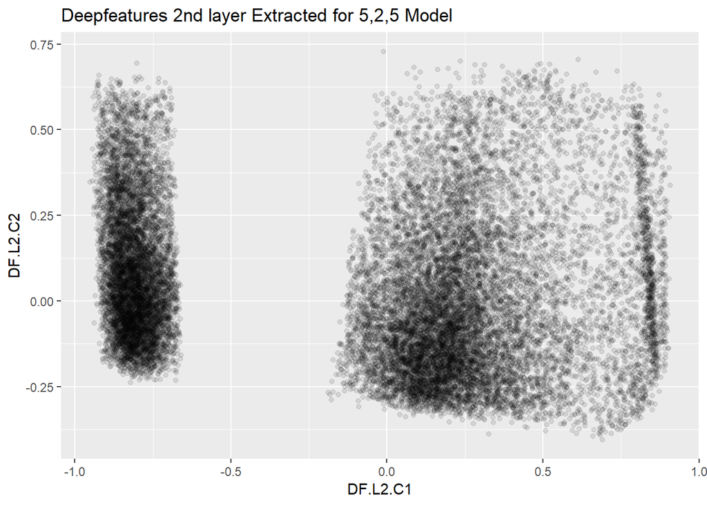

```r
ggplot(train_features, aes(DF.L2.C1, DF.L2.C2)) +
  geom_point(alpha = 0.1) +
  ggtitle('Deepfeatures 2nd layer Extracted for 5,2,5 Model')
```